# Final Project Data Memo

Data Science 2 with R (STAT 301-2)

Author

Stuart Sumner

## The Data

This dataset provides Covid-19 data for more than 1 million unique patients, with 21 variables, provided by the Mexican government. You can find more information as well as the codebook at the source on Kaggle.com, [here](https://www.kaggle.com/datasets/meirnizri/covid19-dataset?select=Covid+Data.csv).

```r
library(tidyverse)
library(lubridate)
library(naniar)
library(cowplot)

covid <- read_csv("data/Covid Data.csv") %>%
  janitor::clean_names() %>%
  replace_with_na(replace = list(date_died = "9999-99-99", intubed = 99)) %>%
  mutate(
    age = age,
    usmer = factor(usmer, levels = c(1, 2)),
    sex = factor(sex, levels = c(1, 2), labels = c("F", "M")),
    patient_type = factor(patient_type, levels = c(1, 2), labels = c("home", "hospitalized")),
    date_died = dmy(date_died),
    intubed = factor(intubed, levels = c(1, 97), labels = c("Yes", "No")),
    pneumonia = factor(pneumonia, levels = c(1, 2), labels = c("Yes", "No")),
    pregnant = factor(pregnant, levels = c(1, 2), labels = c("Yes", "No")),
    diabetes = factor(diabetes, levels = c(1, 2), labels = c("Yes", "No")),
    copd = factor(copd, levels = c(1, 2), labels = c("Yes", "No")),
    asthma = factor(asthma, levels = c(1, 2), labels = c("Yes", "No")),
    inmsupr = factor(inmsupr, levels = c(1, 2), labels = c("Yes", "No")),
    hipertension = factor(hipertension, levels = c(1, 2), labels = c("Yes", "No")),
    other_disease = factor(other_disease, levels = c(1, 2), labels = c("Yes", "No")),
    cardiovascular = factor(cardiovascular, levels = c(1, 2), labels = c("Yes", "No")),
    obesity = factor(obesity, levels = c(1, 2), labels = c("Yes", "No")),
    renal_chronic = factor(renal_chronic, levels = c(1, 2), labels = c("Yes", "No")),
    tobacco = factor(tobacco, levels = c(1, 2), labels = c("Yes", "No")),
    clasiffication_final = factor(clasiffication_final, levels = c(1, 2, 3, 4, 5, 6, 7)),
    clasiffication_final = fct_collapse(clasiffication_final,
                                       `1` = "1",
                                       `2` = "2",
                                       `3` = "3",
                                       None = c("4", "5", "6", "7")),
    icu = factor(icu, levels = c(1, 2), labels = c("Yes", "No"))
  ) %>%
  select(-medical_unit, -usmer)

skimr::skim(covid)
```

Data summary

| Name | covid |
| --- | --- |
| Number of rows | 1048575 |
| Number of columns | 19 |
| _______________________ |  |
| Column type frequency: |  |
| Date | 1 |
| factor | 17 |
| numeric | 1 |
| ________________________ |  |
| Group variables | None |

**Variable type: Date**

| skim_variable | n_missing | complete_rate | min | max | median | n_unique |
| --- | --- | --- | --- | --- | --- | --- |
| date_died | 971633 | 0.07 | 2020-01-02 | 2021-05-02 | 2020-06-11 | 400 |

**Variable type: factor**

| skim_variable | n_missing | complete_rate | ordered | n_unique | top_counts |
| --- | --- | --- | --- | --- | --- |
| sex | 0 | 1.00 | FALSE | 2 | F: 525064, M: 523511 |
| patient_type | 0 | 1.00 | FALSE | 2 | hom: 848544, hos: 200031 |
| intubed | 166375 | 0.84 | FALSE | 2 | No: 848544, Yes: 33656 |
| pneumonia | 16003 | 0.98 | FALSE | 2 | No: 892534, Yes: 140038 |
| pregnant | 527265 | 0.50 | FALSE | 2 | No: 513179, Yes: 8131 |
| diabetes | 3338 | 1.00 | FALSE | 2 | No: 920248, Yes: 124989 |
| copd | 3003 | 1.00 | FALSE | 2 | No: 1030510, Yes: 15062 |
| asthma | 2979 | 1.00 | FALSE | 2 | No: 1014024, Yes: 31572 |
| inmsupr | 3404 | 1.00 | FALSE | 2 | No: 1031001, Yes: 14170 |
| hipertension | 3104 | 1.00 | FALSE | 2 | No: 882742, Yes: 162729 |
| other_disease | 5045 | 1.00 | FALSE | 2 | No: 1015490, Yes: 28040 |
| cardiovascular | 3076 | 1.00 | FALSE | 2 | No: 1024730, Yes: 20769 |
| obesity | 3032 | 1.00 | FALSE | 2 | No: 885727, Yes: 159816 |
| renal_chronic | 3006 | 1.00 | FALSE | 2 | No: 1026665, Yes: 18904 |
| tobacco | 3220 | 1.00 | FALSE | 2 | No: 960979, Yes: 84376 |
| clasiffication_final | 0 | 1.00 | FALSE | 4 | Non: 656596, 3: 381527, 1: 8601, 2: 1851 |
| icu | 856032 | 0.18 | FALSE | 2 | No: 175685, Yes: 16858 |

**Variable type: numeric**

| skim_variable | n_missing | complete_rate | mean | sd | p0 | p25 | p50 | p75 | p100 | hist |
| --- | --- | --- | --- | --- | --- | --- | --- | --- | --- | --- |
| age | 0 | 1 | 41.79 | 16.91 | 0 | 30 | 40 | 53 | 121 | ▂▇▅▁▁ |

I’ve performed a quick skim of the processed data. Note the amount of missingness in some of these columns, especially ‘pregnant’, ‘icu’, and ‘date_died’. This is going to be a big question in how to move forward with the analysis and may require some assumptions on my part. A further exploration will show that there are a little over 8,000 pregnant patients and over 500,000 non-pregnant patients. Because these numbers don’t seem too unrealistic to me, I will treat those NA’s as true NA’s, unmeasured values. The same can be said for icu. Because both these measures are so under-completed, I plan to drop them from my analysis rather than try to impute values. For ‘date_died’, however, I will recode NA’s as meaning the patient survived, which I think is a safe assumption. For all other variables, I plan to impute the missing values as their completion rate is much higher and, again, this dataset is large.

## Analysis

I don’t foresee any other major issues there, so I can think about splitting my data and start formulating a recipe. I plan to split my data with 80% training 20% testing as this is a large dataset, stratifying by my outcome variable (‘patient_type’). The outcome variable depicts whether the patient was sent home or hospitalized. I am stratifying by this variable to ensure that both sent home and hospitalized patients are proportionally represented in each level of my analysis. I plan to use logistic regression and, rather than predict a binary, predict the probability that the patient was hospitalized based on predictor variables. See below for visuals regarding the outcome variable.

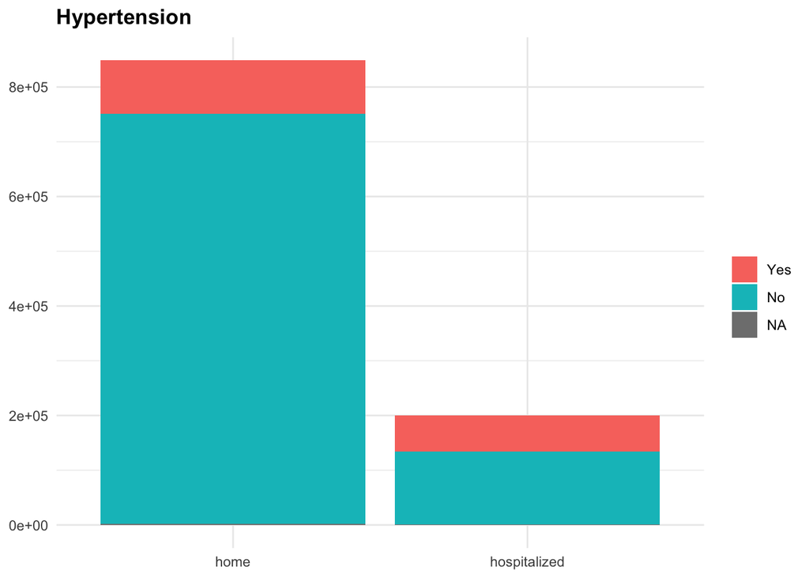

```r
a <- ggplot(covid, aes(patient_type)) +
  geom_bar(aes(fill = hipertension))

b <- ggplot(covid, aes(patient_type)) +
  geom_bar(aes(fill = pneumonia))

c <- ggplot(covid, aes(patient_type)) +
  geom_bar(aes(fill = tobacco))



a +
  theme_minimal() +
  theme(
    axis.title = element_blank(),
    legend.title = element_blank(),
    plot.title = element_text(face = "bold")
  ) +
  labs(title = "Hypertension")
```

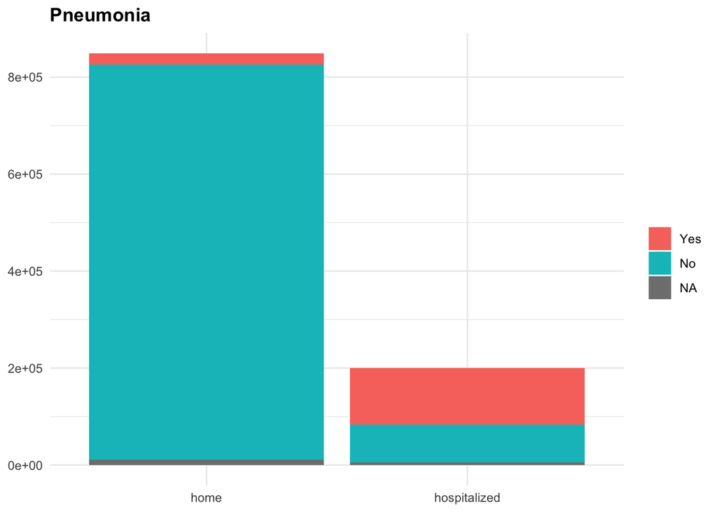

```r
b +
  theme_minimal() +
  theme(
    axis.title = element_blank(),
    legend.title = element_blank(),
    plot.title = element_text(face = "bold")
  ) +
  labs(title = "Pneumonia")
```

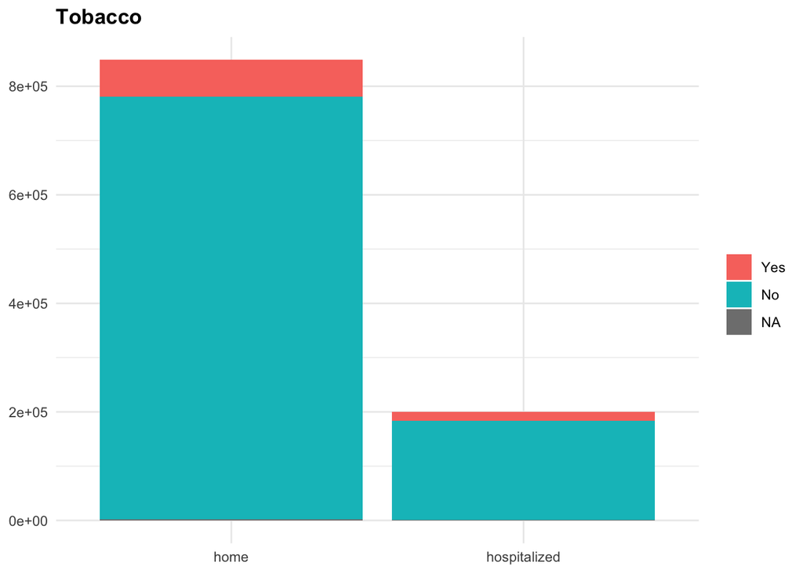

```r
c +
  theme_minimal() +
  theme(
    axis.title = element_blank(),
    legend.title = element_blank(),
    plot.title = element_text(face = "bold")
  ) +
  labs(title = "Tobacco")
```

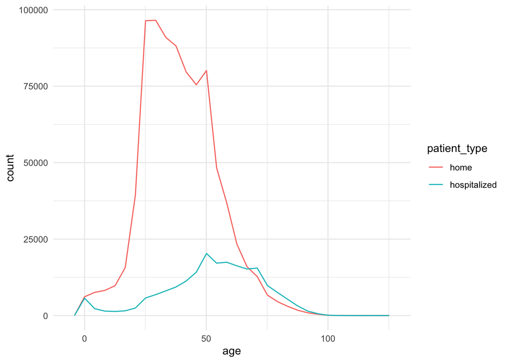

```r
ggplot(covid, aes(age)) +
  geom_freqpoly(aes(color = patient_type)) +
  theme_minimal()
```

I would also like to use resampling to strengthen my models. This is a large dataset, so using too many repeats or folds may create a large time constraint– for this reason, I’m not yet sure what values I want to use for both. I feel confident moving forward that I can create an appropriate recipe and workflow for multiple models soon.